# CEU Machine Learning Tools - Session 1

János Divényi

```r
library(tidyverse)
library(glmnet)
library(rpart)  # for Tree
library(ranger)  # for Random Forest
theme_set(theme_minimal())
```

## Predict the demand for bike share using known tools

Our goal is to predict demand for bike share based on [this](https://www.kaggle.com/c/bike-sharing-demand) Kaggle task. Kaggle provides two data sets: a labelled train data and an unlabelled test data. We have to use the train data to predict labels for the test data. Kaggle won’t give us the labels just a score we achieved on the test set.

Sample set

```r
# kaggle data, the test set cannot be used for our test purposes
bike_data <- read_csv("../data/bike_sharing_demand/bike_sample.csv")
skimr::skim(bike_data)
```

Data summary

| Name | bike_data |
| --- | --- |
| Number of rows | 2177 |
| Number of columns | 12 |
| _______________________ |  |
| Column type frequency: |  |
| numeric | 11 |
| POSIXct | 1 |
| ________________________ |  |
| Group variables | None |

**Variable type: numeric**

| skim_variable | n_missing | complete_rate | mean | sd | p0 | p25 | p50 | p75 | p100 | hist |
| --- | --- | --- | --- | --- | --- | --- | --- | --- | --- | --- |
| season | 0 | 1 | 2.54 | 1.12 | 1.00 | 2.00 | 3.00 | 4.00 | 4.00 | ▇▇▁▇▇ |
| holiday | 0 | 1 | 0.03 | 0.17 | 0.00 | 0.00 | 0.00 | 0.00 | 1.00 | ▇▁▁▁▁ |
| workingday | 0 | 1 | 0.68 | 0.46 | 0.00 | 0.00 | 1.00 | 1.00 | 1.00 | ▃▁▁▁▇ |
| weather | 0 | 1 | 1.43 | 0.64 | 1.00 | 1.00 | 1.00 | 2.00 | 3.00 | ▇▁▃▁▁ |
| temp | 0 | 1 | 20.25 | 7.79 | 0.82 | 13.94 | 20.50 | 27.06 | 41.00 | ▂▇▇▇▁ |
| atemp | 0 | 1 | 23.61 | 8.44 | 2.28 | 16.66 | 24.24 | 31.06 | 43.94 | ▂▆▇▇▂ |
| humidity | 0 | 1 | 62.01 | 19.29 | 0.00 | 47.00 | 62.00 | 78.00 | 100.00 | ▁▃▇▇▅ |
| windspeed | 0 | 1 | 13.02 | 8.15 | 0.00 | 7.00 | 13.00 | 17.00 | 48.00 | ▇▇▃▁▁ |
| casual | 0 | 1 | 36.56 | 51.01 | 0.00 | 4.00 | 17.00 | 49.00 | 362.00 | ▇▁▁▁▁ |
| registered | 0 | 1 | 155.79 | 151.05 | 0.00 | 37.00 | 120.00 | 224.00 | 886.00 | ▇▃▁▁▁ |
| count | 0 | 1 | 192.34 | 181.46 | 1.00 | 44.00 | 147.00 | 284.00 | 977.00 | ▇▃▁▁▁ |

**Variable type: POSIXct**

| skim_variable | n_missing | complete_rate | min | max | median | n_unique |
| --- | --- | --- | --- | --- | --- | --- |
| datetime | 0 | 1 | 2011-01-01 | 2012-12-19 17:00:00 | 2011-12-17 12:00:00 | 2177 |

```r
n_obs <- nrow(bike_data)
test_share <- 0.25

set.seed(20230308)
test_indices <- sample(seq(n_obs), floor(test_share * n_obs))
bike_test <- slice(bike_data, test_indices)
bike_train <- slice(bike_data, -test_indices)
```

Kaggle will use the Root Mean Squared Log Error (RMSLE) to evaluate the predictions. It has the advantage that one could interpret this as a relative error (as the log difference is very close to the relative difference for small errors).

To avoid our RMSLE throwing an error, we have to ensure that our predictions are never negative. In our case, it won’t make any sense either, as demand cannot be negative. Our models do not know that so we need to adjust negative predictions to zero.

```r
calculateRMSLE <- function(prediction, y_obs) {
    sqrt(mean((log(ifelse(prediction < 0, 0, prediction) + 1) - log(y_obs + 1))^2))
}
```

```r
# estimate some benchmark models (e.g. avg)
avg <- mean(bike_train$count)
rmsle_results <- tibble(
    model = "Avg",
    train = calculateRMSLE(avg, bike_train$count),
    test = calculateRMSLE(avg, bike_test$count)
)
rmsle_results
```

| model | train | test |
| --- | --- | --- |
| Avg | 1.561 | 1.56 |

```r
group_averages <- lm(
    count ~ as.factor(season) + as.factor(holiday) + as.factor(workingday),
    data = bike_train
)
rmsle_results <- add_row(rmsle_results,
    model = "Group-avg",
    train = calculateRMSLE(predict(group_averages, bike_train), bike_train$count),
    test = calculateRMSLE(predict(group_averages, bike_test), bike_test$count)
)
rmsle_results
```

| model | train | test |
| --- | --- | --- |
| Avg | 1.561 | 1.56 |
| Group-avg | 1.515 | 1.51 |

```r
linear <- lm(
    count ~ as.factor(season) + as.factor(holiday) + as.factor(workingday) + as.factor(weather) + temp + atemp + humidity + windspeed,
    data = bike_train
)

rmsle_results <- add_row(rmsle_results,
    model = "Linear",
    train = calculateRMSLE(predict(linear), bike_train$count),
    test = calculateRMSLE(predict(linear, bike_test), bike_test$count)
)
rmsle_results
```

| model | train | test |
| --- | --- | --- |
| Avg | 1.561 | 1.560 |
| Group-avg | 1.515 | 1.510 |
| Linear | 1.386 | 1.419 |

```r
linear_poly <- lm(
    count ~ polym(as.factor(season), as.factor(holiday), as.factor(workingday), as.factor(weather), temp, atemp, humidity, windspeed, raw = TRUE, degree = 4),
    data = bike_train
)

rmsle_results <- add_row(rmsle_results,
    model = "Very flexible linear",
    train = calculateRMSLE(predict(linear_poly), bike_train$count),
    test = calculateRMSLE(predict(linear_poly, bike_test), bike_test$count)
)
rmsle_results
```

| model | train | test |
| --- | --- | --- |
| Avg | 1.561 | 1.560 |
| Group-avg | 1.515 | 1.510 |
| Linear | 1.386 | 1.419 |
| Very flexible linear | 1.254 | 1.899 |

Estimating a linear model on a 4th degree polynomial (including interactions) is naturally an extreme. Our evaluation results clearly show that the model overfits the train data (there is a big difference between the train and the test set errors). The overfit is so bad that our test set performance is clearly worse than what our benchmark model achieves.

Let’s solve the problem of overfitting with applying some regularization: run a LASSO model on the same data. In ML1 we run LASSO regressions using the `glmnet()` function. This function expects a matrix parameter that contains the features, and a vector parameter for the outcome. The `cv.glmnet()` finds the best lambda for us by using cross-validation.

```r
# Step 1: write a function that takes the df and returns matrix features (use model.matrix() and polym())
createPolyMatrix <- function(df) {
    model.matrix(
        count ~ polym(
            as.factor(season), as.factor(holiday), as.factor(workingday), as.factor(weather),
            temp, atemp, humidity, windspeed,
            raw = TRUE, degree = 4
        ),
        df
    )
}
# Step 2: create 4-degree polynomial features from the train set
features <- createPolyMatrix(bike_train)
# Step 3: train a LASSO model (use cv.glmnet() to find the best lambda via cross-validation)
lasso <- cv.glmnet(features, bike_train$count, alpha = 1)
# Step 4: evaluate the models on train and test set (use predict(model, features, s = model$lambda.min))
lasso_test_predictions <- predict(lasso, createPolyMatrix(bike_test), s = lasso$lambda.min)
rmsle_results <- add_row(rmsle_results,
    model = "Lasso",
    train = calculateRMSLE(predict(lasso, features, s = lasso$lambda.min), bike_train$count),
    test = calculateRMSLE(lasso_test_predictions, bike_test$count)
)
rmsle_results
```

| model | train | test |
| --- | --- | --- |
| Avg | 1.561 | 1.560 |
| Group-avg | 1.515 | 1.510 |
| Linear | 1.386 | 1.419 |
| Very flexible linear | 1.254 | 1.899 |
| Lasso | 1.279 | 1.311 |

The LASSO indeed solved the overfitting problem. With regularization added to flexibility, we could improve our prediction performance even on the test set.

```r
tree_model <- rpart(
    count ~ as.factor(season) + as.factor(holiday) + as.factor(workingday) + as.factor(weather) + temp + atemp + humidity + windspeed,
    bike_train
)
rmsle_results <- add_row(rmsle_results,
    model = "Tree",
    train = calculateRMSLE(predict(tree_model), bike_train$count),
    test = calculateRMSLE(predict(tree_model, newdata = bike_test), bike_test$count)
)
rmsle_results
```

| model | train | test |
| --- | --- | --- |
| Avg | 1.561 | 1.560 |
| Group-avg | 1.515 | 1.510 |
| Linear | 1.386 | 1.419 |
| Very flexible linear | 1.254 | 1.899 |
| Lasso | 1.279 | 1.311 |
| Tree | 1.378 | 1.372 |

## Improve our models

### Diagnostics

```r
bike_predictions <- select(bike_test, count) |>
    mutate(
        prediction_lm = predict(linear, bike_test),
        prediction_lasso = lasso_test_predictions,
        prediction_tree = predict(tree_model, bike_test)
    )
```

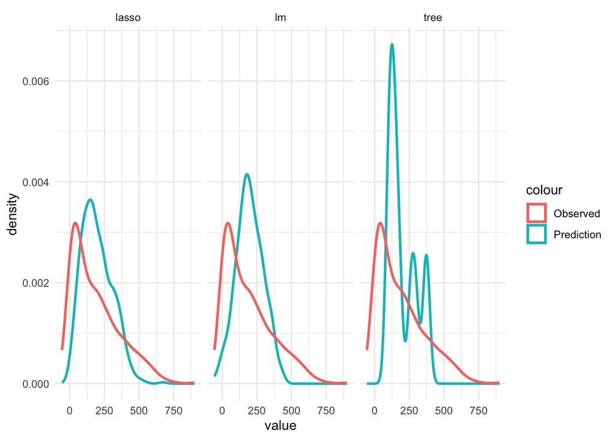

```r
bike_predictions |>
    pivot_longer(starts_with("prediction"), names_prefix = "prediction_") |>
    ggplot() +
    geom_density(aes(x = value, color = "Prediction"), linewidth = 1) +
    geom_density(aes(x = count, color = "Observed"), linewidth = 1) +
    facet_grid(~ name)
```

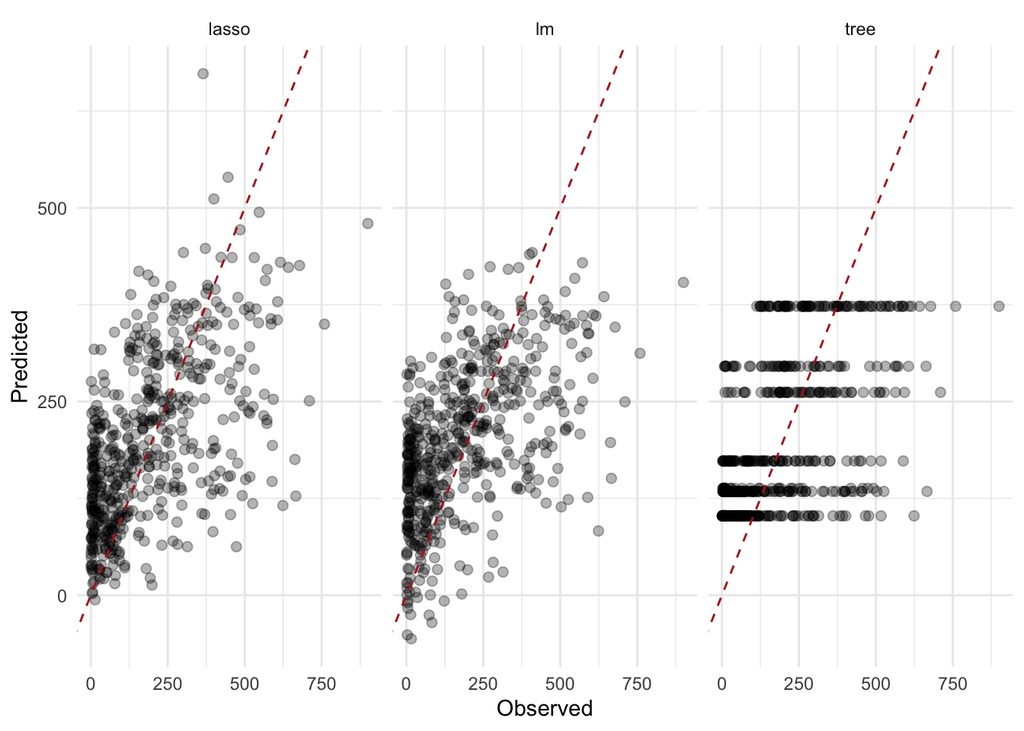

```r
bike_predictions |>
    pivot_longer(starts_with("prediction"), names_prefix = "prediction_") |>
    ggplot(aes(count, value)) +
    geom_point(alpha = 0.3, size = 2) +
    geom_abline(slope = 1, intercept = 0, linetype = "dashed", color = "firebrick") +
    facet_grid(~ name) +
    labs(x = "Observed", y = "Predicted")
```

We might notice from the plots a particular subset of observations where we have hard time with prediction: hours with almost zero demand are usually overpredicted. Let’s take a look a them:

```r
filter(bike_train, count <= 20)
```

| datetime | season | holiday | workingday | weather | temp | atemp | humidity | windspeed | casual | registered | count |
| --- | --- | --- | --- | --- | --- | --- | --- | --- | --- | --- | --- |
| 2011-10-18 03:00:00 | 4 | 0 | 1 | 1 | 18.04 | 21.970 | 94 | 6.003 | 0 | 1 | 1 |
| 2012-09-12 03:00:00 | 3 | 0 | 1 | 1 | 20.50 | 24.240 | 77 | 6.003 | 0 | 7 | 7 |
| 2011-01-06 02:00:00 | 1 | 0 | 1 | 1 | 6.56 | 11.365 | 64 | 0.000 | 0 | 2 | 2 |
| 2011-01-04 00:00:00 | 1 | 0 | 1 | 1 | 6.56 | 9.090 | 55 | 7.002 | 0 | 5 | 5 |
| 2011-04-14 03:00:00 | 2 | 0 | 1 | 1 | 13.94 | 16.665 | 81 | 8.998 | 0 | 2 | 2 |
| 2011-04-18 04:00:00 | 2 | 0 | 1 | 1 | 16.40 | 20.455 | 87 | 11.001 | 2 | 4 | 6 |
| 2012-02-15 01:00:00 | 1 | 0 | 1 | 1 | 13.94 | 18.180 | 53 | 0.000 | 0 | 5 | 5 |
| 2012-05-13 04:00:00 | 2 | 0 | 0 | 2 | 22.14 | 25.760 | 68 | 12.998 | 2 | 7 | 9 |
| 2012-10-07 05:00:00 | 4 | 0 | 0 | 2 | 18.04 | 21.970 | 54 | 8.998 | 2 | 8 | 10 |
| 2012-12-07 04:00:00 | 4 | 0 | 1 | 1 | 10.66 | 13.635 | 75 | 7.002 | 0 | 10 | 10 |

[output cut: 260 more lines]

We can realize that there is an important piece of information we have not used before: the period of day. Demand is close zero between 0 and 5 hour (unsurprisingly). This information was “hidden” in the `datetime` column, which is neither a numeric nor a categorical variable so our models were not able to interpret them. Let’s extract this information by creating some new features. This process is called *feature engineering*.

### Feature engineering: create new variables

```r
createAdditionalFeatures <- function(bike_data, drop = TRUE) {
    new_data <- mutate(bike_data,
        month = as.factor(lubridate::month(datetime)),
        hour = as.factor(lubridate::hour(datetime)),
        weekday = as.factor(weekdays(datetime)),
        across(season:weather, as.factor)
    )
    if (drop) {
        select(new_data, -datetime, -workingday, -casual, -registered)
    } else {
        new_data
    }
}
bike_train_plus <- createAdditionalFeatures(bike_train)
bike_test_plus <- createAdditionalFeatures(bike_test)
```

```r
linear_plus <- lm(count ~ ., bike_train_plus)
rmsle_results <- add_row(rmsle_results,
    model = "Feature-eng linear",
    train = calculateRMSLE(predict(linear_plus), bike_train_plus$count),
    test = calculateRMSLE(predict(linear_plus, bike_test_plus), bike_test_plus$count)
)
rmsle_results
```

| model | train | test |
| --- | --- | --- |
| Avg | 1.561 | 1.560 |
| Group-avg | 1.515 | 1.510 |
| Linear | 1.386 | 1.419 |
| Very flexible linear | 1.254 | 1.899 |
| Lasso | 1.279 | 1.311 |
| Tree | 1.378 | 1.372 |
| Feature-eng linear | 1.065 | 1.080 |

```r
createPolyFeaturesPlus <- function(df) {
    model.matrix(
        count ~ polym(season, holiday, weather, temp, atemp, humidity, windspeed, month, hour, weekday, raw = TRUE, degree = 4),
        data = df
    )
}
plus_features <- createPolyFeaturesPlus(bike_train_plus)
lasso_plus <- cv.glmnet(plus_features, bike_train_plus$count, alpha = 1)
```

```r
rmsle_results <- add_row(rmsle_results,
    model = "Feature-eng LASSO",
    train = calculateRMSLE(predict(lasso_plus, plus_features, s = lasso$lambda.min), bike_train_plus$count),
    test = calculateRMSLE(predict(lasso_plus, createPolyFeaturesPlus(bike_test_plus), s = lasso$lambda.min), bike_test_plus$count)
)
rmsle_results
```

| model | train | test |
| --- | --- | --- |
| Avg | 1.561 | 1.560 |
| Group-avg | 1.515 | 1.510 |
| Linear | 1.386 | 1.419 |
| Very flexible linear | 1.254 | 1.899 |
| Lasso | 1.279 | 1.311 |
| Tree | 1.378 | 1.372 |
| Feature-eng linear | 1.065 | 1.080 |
| Feature-eng LASSO | 1.141 | 1.266 |

Interestingly, the simple linear model performs better than the regularized flexible one. The latter might try to achieve too much: it has 1000+ parameters to optimize for.

```r
tree_plus <- rpart(count ~ ., bike_train_plus)
rmsle_results <- add_row(rmsle_results,
    model = "Feature-eng tree",
    train = calculateRMSLE(predict(tree_plus), bike_train_plus$count),
    test = calculateRMSLE(predict(tree_plus, bike_test_plus), bike_test_plus$count)
)
tail(rmsle_results, 10)
```

| model | train | test |
| --- | --- | --- |
| Avg | 1.561 | 1.5598 |
| Group-avg | 1.515 | 1.5100 |
| Linear | 1.386 | 1.4191 |
| Very flexible linear | 1.254 | 1.8986 |
| Lasso | 1.279 | 1.3114 |
| Tree | 1.378 | 1.3724 |
| Feature-eng linear | 1.065 | 1.0804 |
| Feature-eng LASSO | 1.141 | 1.2662 |
| Feature-eng tree | 0.824 | 0.8617 |

### Add more data

Our original data was a 20% sample of the original one. Let’s mimic collecting more data by considering the whole sample. To ensure that we can compare the results of the larger data to our previous observations we have to keep our test data set intact. This can be achieved by taking out the test observations from the full data set and using the remaining part as our new train set. We implement this operation by using the `anti_join()` function.

```r
bike_full <- read_csv("../data/bike_sharing_demand/train.csv")
bike_train_full <- anti_join(bike_full, bike_test)
```

```r
bike_train_full_plus <- createAdditionalFeatures(bike_train_full)
```

```r
linear_full_plus <- lm(count ~ ., bike_train_full_plus)
rmsle_results <- add_row(rmsle_results,
    model = "Feature-eng linear large n",
    train = calculateRMSLE(predict(linear_full_plus), bike_train_full_plus$count),
    test = calculateRMSLE(predict(linear_full_plus, bike_test_plus), bike_test_plus$count)
)
tail(rmsle_results, 10)
```

| model | train | test |
| --- | --- | --- |
| Avg | 1.561 | 1.5598 |
| Group-avg | 1.515 | 1.5100 |
| Linear | 1.386 | 1.4191 |
| Very flexible linear | 1.254 | 1.8986 |
| Lasso | 1.279 | 1.3114 |
| Tree | 1.378 | 1.3724 |
| Feature-eng linear | 1.065 | 1.0804 |
| Feature-eng LASSO | 1.141 | 1.2662 |
| Feature-eng tree | 0.824 | 0.8617 |
| Feature-eng linear large n | 1.062 | 1.0594 |

```r
full_plus_features <- createPolyFeaturesPlus(bike_train_full_plus)
lasso_full_plus <- cv.glmnet(full_plus_features, bike_train_full_plus$count, alpha = 1)

rmsle_results <- add_row(rmsle_results,
    model = "Feature-eng LASSO large n",
    train = calculateRMSLE(predict(lasso_full_plus, full_plus_features, s = lasso$lambda.min), bike_train_full_plus$count),
    test = calculateRMSLE(predict(lasso_full_plus, createPolyFeaturesPlus(bike_test_plus), s = lasso$lambda.min), bike_test_plus$count)
)
tail(rmsle_results, 10)
```

| model | train | test |
| --- | --- | --- |
| Group-avg | 1.515 | 1.5100 |
| Linear | 1.386 | 1.4191 |
| Very flexible linear | 1.254 | 1.8986 |
| Lasso | 1.279 | 1.3114 |
| Tree | 1.378 | 1.3724 |
| Feature-eng linear | 1.065 | 1.0804 |
| Feature-eng LASSO | 1.141 | 1.2662 |
| Feature-eng tree | 0.824 | 0.8617 |
| Feature-eng linear large n | 1.062 | 1.0594 |
| Feature-eng LASSO large n | 1.181 | 1.2102 |

```r
tree_full_plus <- rpart(count ~ ., data = bike_train_full_plus)
rmsle_results <- add_row(rmsle_results,
    model = "Feature-eng tree large n",
    train = calculateRMSLE(predict(tree_full_plus), bike_train_full$count),
    test = calculateRMSLE(predict(tree_full_plus, bike_test_plus), bike_test$count)
)
tail(rmsle_results, 10)
```

| model | train | test |
| --- | --- | --- |
| Linear | 1.3859 | 1.4191 |
| Very flexible linear | 1.2537 | 1.8986 |
| Lasso | 1.2794 | 1.3114 |
| Tree | 1.3778 | 1.3724 |
| Feature-eng linear | 1.0646 | 1.0804 |
| Feature-eng LASSO | 1.1415 | 1.2662 |
| Feature-eng tree | 0.8240 | 0.8617 |
| Feature-eng linear large n | 1.0623 | 1.0594 |
| Feature-eng LASSO large n | 1.1810 | 1.2102 |
| Feature-eng tree large n | 0.8231 | 0.8185 |

Interestingly, our linear models hardly improve when trained on a much bigger dataset. This might be caused by the fact that these models are relatively rigid, and they could have been estimated quite well on the smaller data set as well.

### Train more flexible models

Let’s try some more flexible models now. We expect them to perform better on the test set, especially, if they are fed enough data.

```r
# estimate a random forest using the ranger() using the original feature engineered data
# (just call it with the default options without any hyper-parameter tuning)
# evaluate its performance on train and test sets
rf_plus <- ranger(count ~ ., data = bike_train_plus)

rmsle_results <- add_row(rmsle_results,
    model = "Feature-eng RF",
    train = calculateRMSLE(predict(rf_plus, bike_train_plus)$predictions, bike_train_plus$count),
    test = calculateRMSLE(predict(rf_plus, bike_test_plus)$predictions, bike_test_plus$count)
)
tail(rmsle_results, 10)
```

| model | train | test |
| --- | --- | --- |
| Very flexible linear | 1.2537 | 1.8986 |
| Lasso | 1.2794 | 1.3114 |
| Tree | 1.3778 | 1.3724 |
| Feature-eng linear | 1.0646 | 1.0804 |
| Feature-eng LASSO | 1.1415 | 1.2662 |
| Feature-eng tree | 0.8240 | 0.8617 |
| Feature-eng linear large n | 1.0623 | 1.0594 |
| Feature-eng LASSO large n | 1.1810 | 1.2102 |
| Feature-eng tree large n | 0.8231 | 0.8185 |
| Feature-eng RF | 0.4774 | 0.7469 |

```r
# redo the previos task on the full data
rf_full_plus <- ranger(count ~ ., data = bike_train_full_plus)

rmsle_results <- add_row(rmsle_results,
    model = "Feature-eng RF large n",
    train = calculateRMSLE(predict(rf_full_plus, bike_train_full_plus)$predictions, bike_train_full_plus$count),
    test = calculateRMSLE(predict(rf_full_plus, bike_test_plus)$predictions, bike_test_plus$count)
)
tail(rmsle_results, 10)
```

| model | train | test |
| --- | --- | --- |
| Lasso | 1.2794 | 1.3114 |
| Tree | 1.3778 | 1.3724 |
| Feature-eng linear | 1.0646 | 1.0804 |
| Feature-eng LASSO | 1.1415 | 1.2662 |
| Feature-eng tree | 0.8240 | 0.8617 |
| Feature-eng linear large n | 1.0623 | 1.0594 |
| Feature-eng LASSO large n | 1.1810 | 1.2102 |
| Feature-eng tree large n | 0.8231 | 0.8185 |
| Feature-eng RF | 0.4774 | 0.7469 |
| Feature-eng RF large n | 0.3747 | 0.5541 |

## Submit to Kaggle

As a last step, let’s submit our best model to Kaggle to evaluate its performance on the Kaggle test set. We might want to retrain this model using all of the data that is available to us. We can expect the final RMSLE on the Kaggle to be somewhat larger than what our test set showed even if we use more data to train it. We have two reasons for this: First, we used the test set to choose our best model, so it ceased to remain a real hold-out set as our best model depends on it (this is a general concern). Second, we created our test set just randomly whereas Kaggle assigned the days from the 20th onwards of each month to the test set. Thus, our way of choosing the test set was a kind of cheating.

```r
kaggle_test <- read_csv("../data/bike_sharing_demand/test.csv")
predictions <- predict(rf_full_plus, createAdditionalFeatures(kaggle_test, drop = FALSE))$predictions
select(kaggle_test, datetime) |>
    mutate(count = predictions) |>
    write.csv("../data/bike_sharing_demand/kaggle_submission.csv", row.names = FALSE)
```